# Section 5 Analysis

Author

Anonymous

Published

2026-04-07

Read in response data:

```r
raw_df <- read_csv(here::here("data", "part2", "exp2-pilot.csv")) %>%
  as_tibble(.) %>%
  filter(status != "rejected")

pilot_df <- raw_df %>% filter(responseId != "windowEvents")

# participant-relevant df
# i.e., the part that is relevant for pixelsPerMM and distToScreen
participant_df <- pilot_df %>%
  filter(str_detect(trialId, "chinrest")) %>%
  select(participantId, responseId, answer) %>%
  filter(
    str_detect(responseId, "pixelsPerMM") |
      str_detect(responseId, "dist-calibration-MM")
  ) %>%
  mutate(answer = as.numeric(answer)) %>%
  pivot_wider(names_from = responseId, values_from = answer) %>%
  dplyr::rename(distToScreen = `dist-calibration-MM`)

# part 1 relevant df
part1_df <- pilot_df %>%
  filter(str_detect(trialId, "block5_test")) %>%
  select(participantId, trialOrder, responseId, answer) %>%
  mutate(answer = as.numeric(answer)) %>%
  pivot_wider(names_from = responseId, values_from = answer) %>%
  dplyr::rename(
    num.ans.x = `location-x`,
    num.ans.y = `location-y`,
    num.resp.x = `slider-x`,
    num.resp.y = `slider-y`,
    px.resp.x = `px-slider-x`,
    px.resp.y = `px-slider-y`,
    px.ans.x = `px-location-x`,
    px.ans.y = `px-location-y`
  )

# part 2 relevant df
part2_df <- pilot_df %>%
  filter(str_detect(trialId, "task")) %>%
  select(
    participantId,
    trialOrder,
    trialId,
    responseId,
    condition,
    answer,
    parameters_taskType,
    parameters_taskIndex
  ) %>%
  pivot_wider(names_from = responseId, values_from = answer) %>%
  dplyr::rename(
    type = parameters_taskType,
    ogIndex = parameters_taskIndex,
    px.resp.y = pixelResponse,
    num.resp.y = numericResponse
  ) %>%
  mutate(
    px.resp.y = as.numeric(px.resp.y),
    num.resp.y = as.numeric(num.resp.y),
    type = ifelse(type == "pointArc", "point_arc", "point")
  )

# join to make the participant_df also contain condition
participant_df <- participant_df %>%
  left_join(
    part2_df %>%
      select(-condition) %>%
      separate_wider_delim(
        trialId,
        delim = "_",
        names = c("condition", "A", "B")
      ) %>%
      select(participantId, condition) %>%
      unique(.)
  )
```

Read in stimuli data for experiment 2 from Moritz et al.:

```r
exp_json_data <- jsonlite::fromJSON(here::here(
  "data",
  "moritz",
  "stimuli",
  "exp2-stimuli.json"
)) %>%
  as_tibble(.)

stimuli_df <- exp_json_data %>%
  select(index, seed, noise, flip, type, data) %>%
  mutate(noise = as.character(noise))

# get the mapping between og index and the index used in exp
stimuli_df %>%
  filter(type == "point") %>%
  mutate(expIndex = 1:nrow(.)) %>%
  select(index, type, expIndex) -> point_map
stimuli_df %>%
  filter(type == "point_arc") %>%
  mutate(expIndex = 1:nrow(.)) %>%
  select(index, type, expIndex) -> pointArc_map

# get rid of the type that we don't use
stimuli_df <- stimuli_df %>% filter(type != "line")

# get the answer
part2.ans_df <- stimuli_df %>%
  unnest(col = data) %>%
  dplyr::rename(num.x = x, num.y = y, ogIndex = index) %>%
  dplyr::summarise(
    num.mean.y = mean(num.y),
    num.median.y = median(num.y),
    .by = c(ogIndex, type, flip, noise, seed)
  ) %>%
  mutate(
    # this is what Moritz did, and what we're not doing
    # num.ans.y = num.mean.y[type == "point"][[1]],
    num.ans.y = num.mean.y,
    .by = c(flip, noise, seed)
  )
```

Read in helper functions for transforming between spaces:

```r
# First Part -- Block 5
x_block5 <- make_va_scale(
  data_min = -5,
  data_max = 5,
  px_min = 50,
  px_max = 585
)
y_block5 <- make_va_scale(
  data_min = 0,
  data_max = 10,
  px_min = 410,
  px_max = 15
)

# Second part -- Mortiz et al. related
x_moritz <- make_va_scale(
  data_min = 0,
  data_max = 120,
  px_min = 0,
  px_max = 500
)
y_moritz <- make_va_scale(data_min = 0, data_max = 1, px_min = 200, px_max = 0)
```

**NoteSee whether data is sampling correctly**

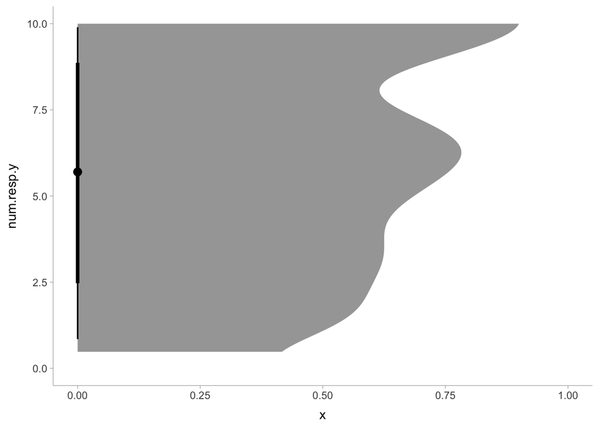

```r
# get a sense of the distribution of part1_df
part1_df %>%
  ggplot(aes(y = num.resp.y)) +
  stat_halfeye() +
  coord_cartesian(ylim = c(0, 10))
```

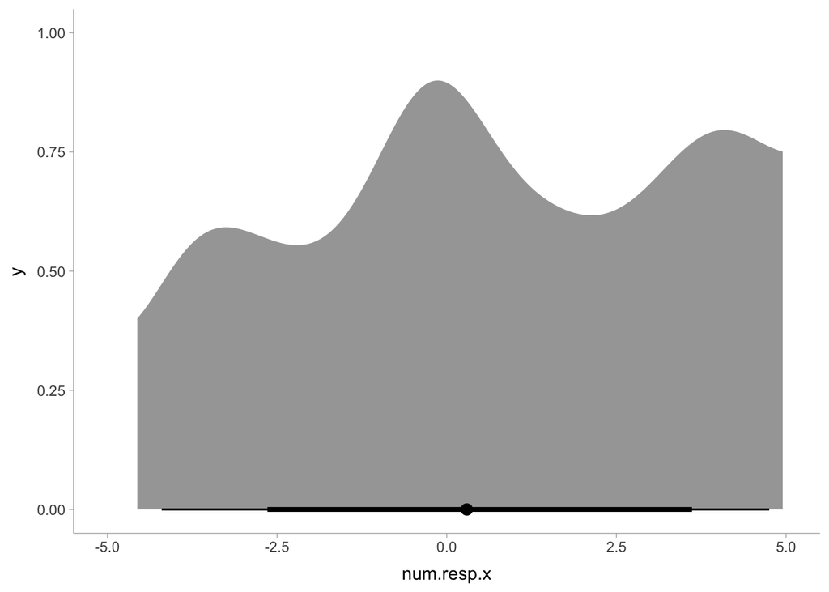

```r
part1_df %>%
  ggplot(aes(x = num.resp.x)) +
  stat_halfeye() +
  coord_cartesian(xlim = c(-5, 5))
```

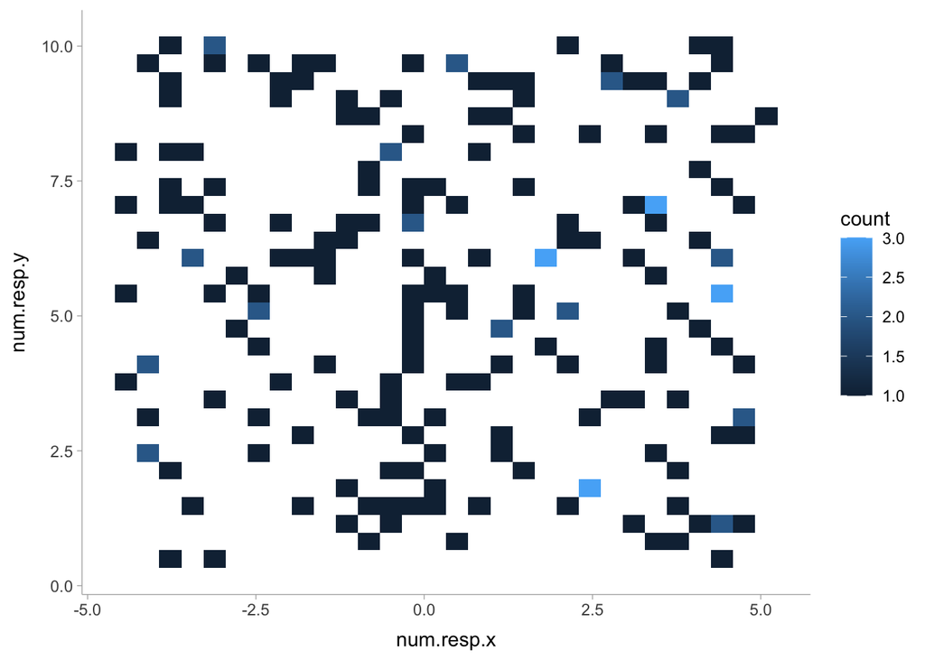

```r
part1_df %>% ggplot(aes(x = num.resp.x, y = num.resp.y)) + geom_bin2d()
```

The above tells us that data is being sampled correctly.

# Fit model for part 1

## Get the data ready

… by adding the visual angle transformed data.

```r
part1_df <- part1_df %>%
  left_join(participant_df) %>%
  mutate(
    va.ans.x = x_block5$data_to_va(num.ans.x, distToScreen, pixelsPerMM),
    va.ans.y = y_block5$data_to_va(num.ans.y, distToScreen, pixelsPerMM),
    va.resp.x = x_block5$data_to_va(num.resp.x, distToScreen, pixelsPerMM),
    va.resp.y = y_block5$data_to_va(num.resp.y, distToScreen, pixelsPerMM)
  ) %>%
  mutate(va.error.x = va.resp.x - va.ans.x, va.error.y = va.resp.y - va.ans.y)
```

Get a sense of error distribution

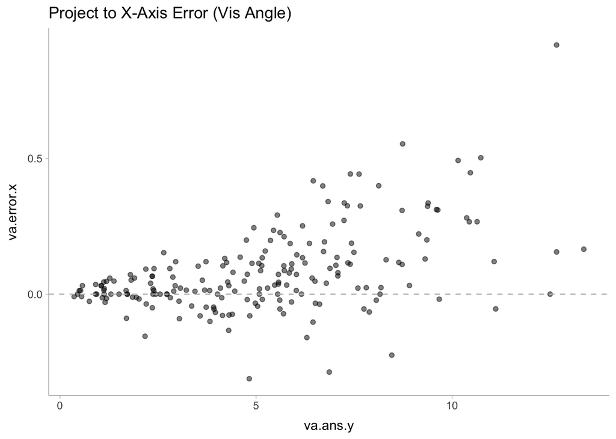

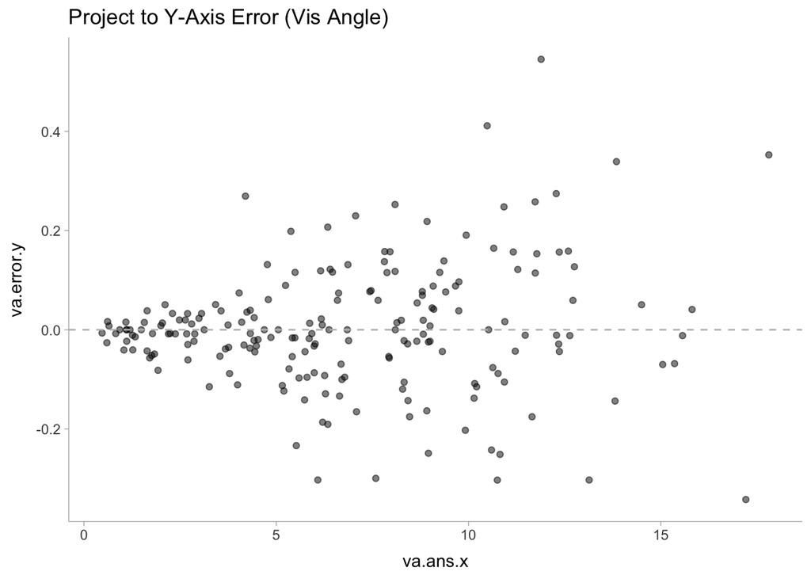

```r
part1_df %>%
  ggplot(aes(y = va.error.x, x = va.ans.y)) +
  geom_point(alpha = 0.5) +
  geom_hline(yintercept = 0, linetype = "dashed", color = "gray") +
  labs(title = "Project to X-Axis Error (Vis Angle)")
part1_df %>%
  ggplot(aes(y = va.error.y, x = va.ans.x)) +
  geom_point(alpha = 0.5) +
  geom_hline(yintercept = 0, linetype = "dashed", color = "gray") +
  labs(title = "Project to Y-Axis Error (Vis Angle)")
```

Note that for matching with part 2, we are *only interested in the second graph* for model fitting purposes.

## Model Specification

Recall the we defined the following model for the “project from dot to axis” operator:

$$\begin{align*}
\texttt{error}_i &\sim \mathcal{N}(\beta_0 + u_{\text{PID[i]}}, \sigma_{i, \text{PID}[i]}) \\
\log(\sigma_{i, j}) &= \alpha_j + \log(\texttt{va.ans.x}_i) \\
\text{or:} \log(\sigma_{i, j}) &\sim \mathcal{N}(\mu_\alpha + \log(\texttt{va.ans.x}_i), \sigma_\alpha)\\
\alpha_j &\sim N(\mu_\alpha, \sigma_\alpha) \\
\mu_\alpha &\sim N(0, 1) \\
\sigma_\alpha &\sim \mathcal{N}^+(0, 1)
\end{align*}$$

Here is the specification we used for fitting:

```r
# Recall that we defined error = resp - ans
f <- bf(
  va.error.y ~ (1 | participantId),
  sigma ~ (1 | participantId) + offset(log(va.ans.x))
)

p <- c(
  prior(normal(0, 1), class = Intercept),
  prior(normal(0, 1), class = sd, group = participantId, lb = 0),
  prior(normal(0, 1), class = Intercept, dpar = "sigma"),
  prior(normal(0, 1), class = sd, group = participantId, dpar = sigma, lb = 0)
)
```

Fit the model:

```r
m1 <- part1_df %>%
  brm(
    formula = f,
    data = .,
    family = gaussian(),
    prior = p,
    chains = 4,
    cores = 4,
    control = list(adapt_delta = 0.99),
    iter = 6000,
    file = here::here("analysis", "fitted_models", "part2", "m1"),
    file_refit = "on_change",
    save_pars = save_pars(all = TRUE)
  )
```

Get a sense of posterior fit:

```r
summary(m1)
```

```
 Family: gaussian
  Links: mu = identity; sigma = log
Formula: va.error.y ~ (1 | participantId)
         sigma ~ (1 | participantId) + offset(log(va.ans.x))
   Data: . (Number of observations: 200)
  Draws: 4 chains, each with iter = 6000; warmup = 3000; thin = 1;
         total post-warmup draws = 12000

Multilevel Hyperparameters:
~participantId (Number of levels: 20)
                    Estimate Est.Error l-95% CI u-95% CI Rhat Bulk_ESS Tail_ESS
sd(Intercept)           0.02      0.01     0.01     0.04 1.00     3027     4755
sd(sigma_Intercept)     0.25      0.09     0.10     0.44 1.00     4386     5382

Regression Coefficients:
                Estimate Est.Error l-95% CI u-95% CI Rhat Bulk_ESS Tail_ESS
Intercept          -0.01      0.01    -0.03     0.00 1.00     5242     6858
sigma_Intercept    -4.16      0.08    -4.31    -3.99 1.00     7737     7949

Draws were sampled using sample(hmc). For each parameter, Bulk_ESS
and Tail_ESS are effective sample size measures, and Rhat is the potential
scale reduction factor on split chains (at convergence, Rhat = 1).
```

Note that the Bulk_ESS and Tail_ESS all indicate good fit.

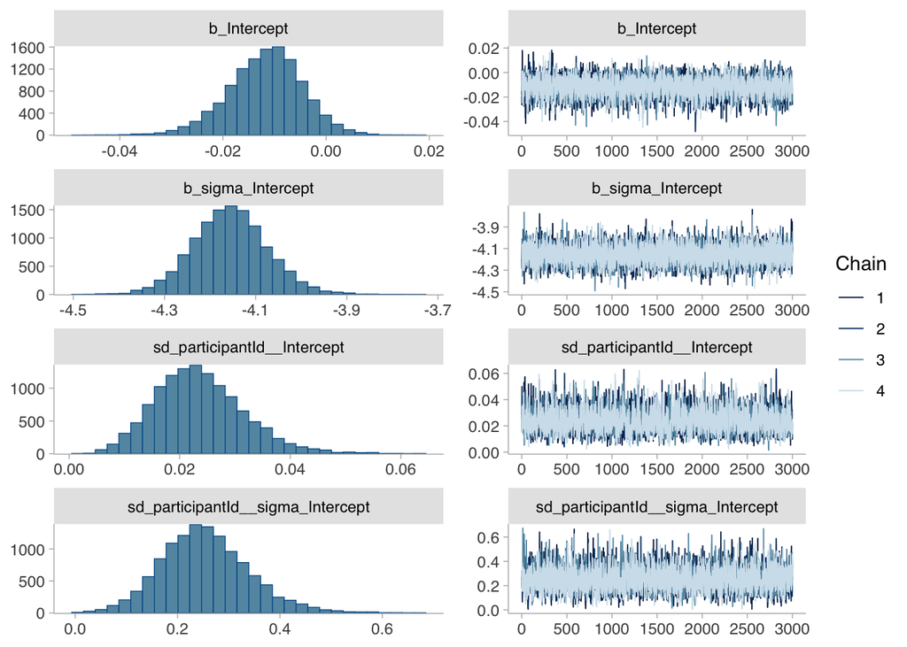

```r
plot(m1)
```

The four chains mix well. Now we move on to perform posterior predictive checks:

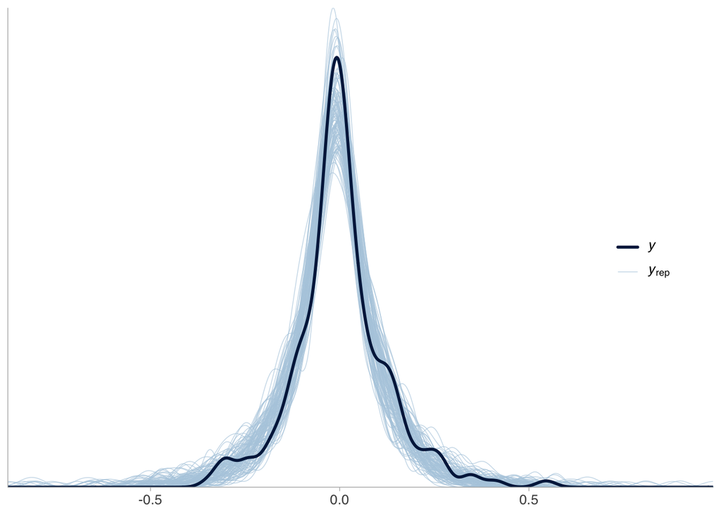

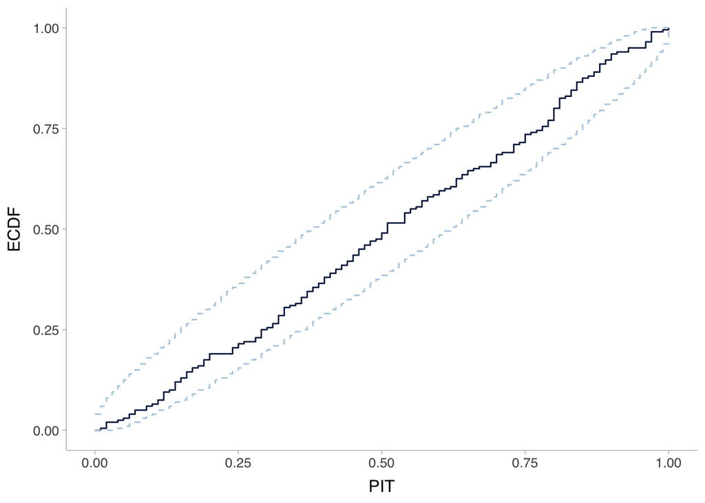

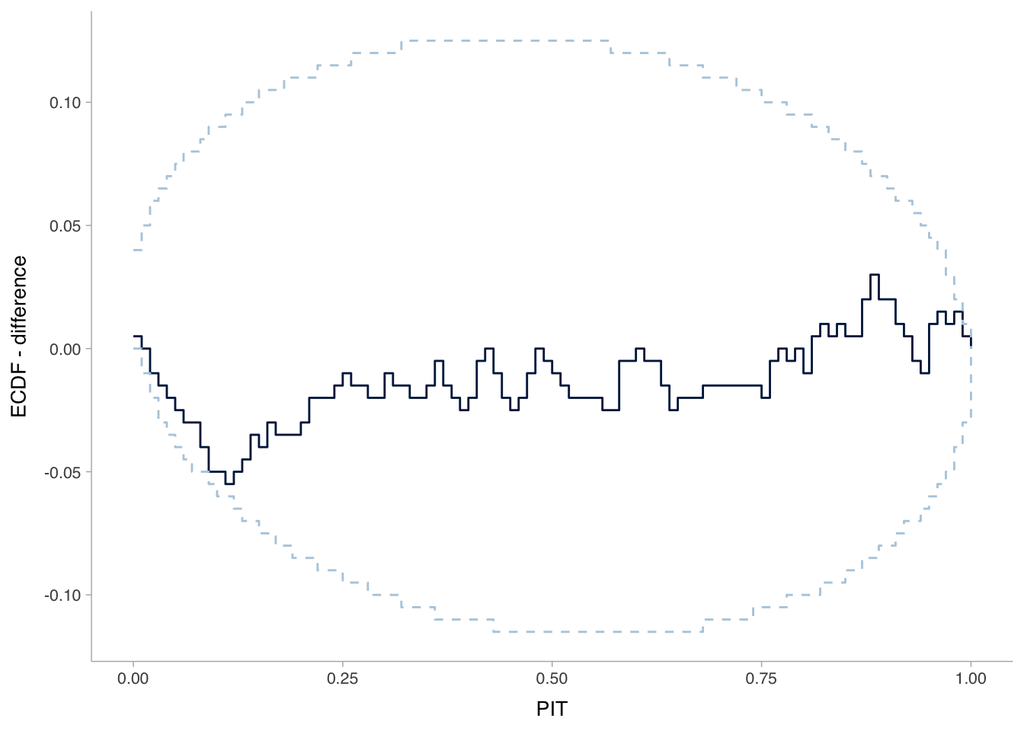

```r
pp_check(m1, ndraws = 100) +
  theme(legend.position = c(0.9, 0.5)) +
  theme(text = element_text(size = 12)) -> p1
p1
pp_check(m1, ndraws = 100, type = "pit_ecdf") +
  theme(text = element_text(size = 12)) -> p2
p2
pp_check(m1, ndraws = 100, type = "pit_ecdf", plot_diff = TRUE) +
  theme(text = element_text(size = 10)) -> p3
p3
```

Plot existing data on top of prediction, for an average participant:

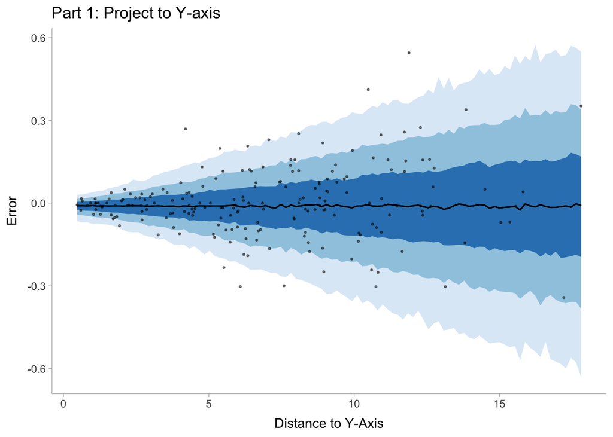

```r
prediction_grid <- part1_df %>%
  modelr::data_grid(
    va.ans.x = modelr::seq_range(va.ans.x, n = 100),
    participantId = unique(participantId)
  ) %>%
  add_predicted_draws(m1, ndraws = 100)

ggplot(prediction_grid, aes(x = va.ans.x, y = .prediction)) +
  stat_lineribbon(
    .width = c(.95, .80, .50),
    # alpha = 0.5,
    linewidth = 0.5
  ) +
  scale_fill_brewer(palette = "Blues") +
  geom_point(
    data = part1_df,
    aes(y = va.error.y, x = va.ans.x),
    alpha = 0.5,
    size = 0.5
  ) +
  labs(
    title = "Part 1: Project to Y-axis",
    y = "Error",
    x = "Distance to Y-Axis"
  ) +
  # theme_minimal(base_size = 8) +
  # coord_cartesian(ylim = c(-0.25, 0.4)) +
  theme(legend.position = "none") -> p1

p1
```

## Prior sensitivity analysis

**Caution**

The following is quite time-consuming. Only run this if your computer has good power.

To test whether our model is sensitive to prior specifications, we fit them on differnt priors:

```r
# Wider — less informative
p_wide <- c(
  prior(normal(0, 5), class = Intercept),
  prior(normal(0, 5), class = sd, group = participantId, lb = 0),
  prior(normal(0, 5), class = Intercept, dpar = "sigma"),
  prior(normal(0, 5), class = sd, group = participantId, dpar = sigma, lb = 0)
)

# Tighter — more informative
p_tight <- c(
  prior(normal(0, 0.1), class = Intercept),
  prior(normal(0, 0.1), class = sd, group = participantId, lb = 0),
  prior(normal(0, 0.1), class = Intercept, dpar = "sigma"),
  prior(normal(0, 0.1), class = sd, group = participantId, dpar = sigma, lb = 0)
)

# Different family — heavier tails
p_student <- c(
  prior(student_t(3, 0, 1), class = Intercept),
  prior(student_t(3, 0, 1), class = sd, group = participantId, lb = 0),
  prior(student_t(3, 0, 1), class = Intercept, dpar = "sigma"),
  prior(
    student_t(3, 0, 1),
    class = sd,
    group = participantId,
    dpar = sigma,
    lb = 0
  )
)
```

```r
m1_wide <- part1_df %>%
  brm(
    formula = f,
    data = .,
    family = gaussian(),
    prior = p_wide,
    chains = 4,
    cores = 4,
    control = list(adapt_delta = 0.99),
    iter = 6000,
    file = here::here("analysis", "fitted_models", "part2", "m1_wide"),
    file_refit = "on_change",
    save_pars = save_pars(all = TRUE)
  )

m1_tight <- part1_df %>%
  brm(
    formula = f,
    data = .,
    family = gaussian(),
    prior = p_tight,
    chains = 4,
    cores = 4,
    control = list(adapt_delta = 0.99),
    iter = 6000,
    file = here::here("analysis", "fitted_models", "part2", "m1_tight"),
    file_refit = "on_change",
    save_pars = save_pars(all = TRUE)
  )

m1_student <- part1_df %>%
  brm(
    formula = f,
    data = .,
    family = gaussian(),
    prior = p_student,
    chains = 4,
    cores = 4,
    control = list(adapt_delta = 0.99),
    iter = 6000,
    file = here::here("analysis", "fitted_models", "part2", "m1_student"),
    file_refit = "on_change",
    save_pars = save_pars(all = TRUE)
  )
```

All models fit without convergence issues. Now we combine posteriors into a list and plot them:

```r
# Combine posteriors from all models
models <- list(
  "default (0,1)" = m1,
  "wide (0,5)" = m1_wide,
  "tight (0,0.1)" = m1_tight,
  "student_t(3,0,1)" = m1_student
)

combined <- models %>%
  imap_dfr(
    ~ gather_draws(.x, b_Intercept, b_sigma_Intercept) %>%
      mutate(prior = .y)
  )
```

Interval plot:

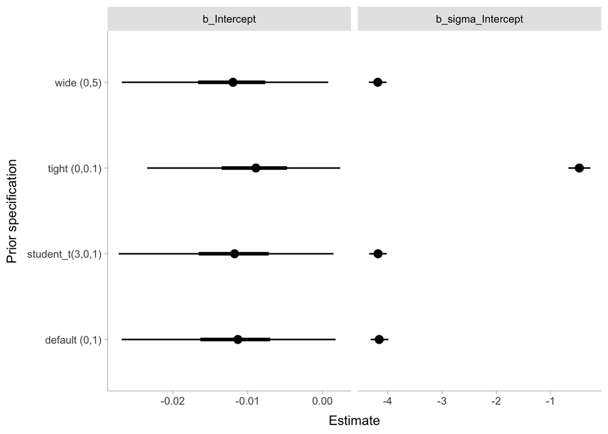

```r
combined %>%
  # uncomment to see what variance instead of log(variance) is.
  # mutate(
  #   .value = if_else(.variable == "b_sigma_Intercept", exp(.value), .value)
  # ) %>%
  ggplot(aes(x = .value, y = prior)) +
  stat_pointinterval(.width = c(.50, .95)) +
  facet_wrap(~.variable, scales = "free_x") +
  labs(x = "Estimate", y = "Prior specification")
```

Densities overlaid:

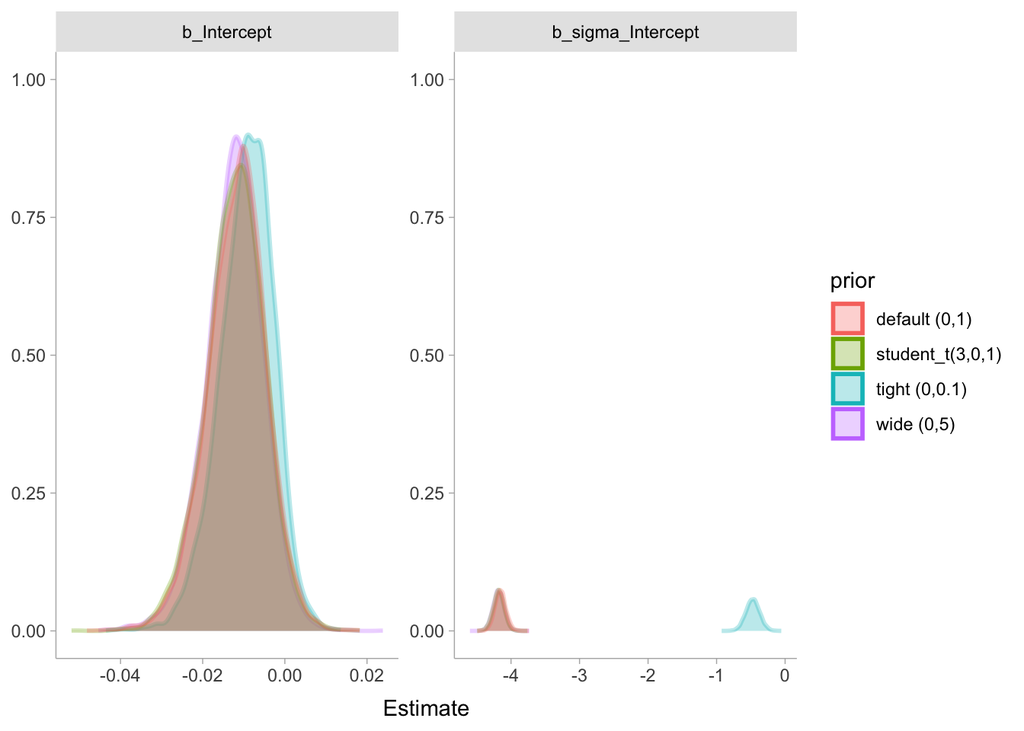

```r
combined %>%
  ggplot(aes(x = .value, color = prior, fill = prior)) +
  stat_slab(alpha = 0.3) +
  facet_wrap(~.variable, scales = "free") +
  labs(x = "Estimate", y = NULL)
```

To see the actual table:

```r
combined %>%
  group_by(prior, .variable) %>%
  median_qi(.value, .width = .95) %>%
  select(prior, .variable, .value, .lower, .upper) %>%
  arrange(.variable, prior)
```

| prior | .variable | .value | .lower | .upper |
| --- | --- | --- | --- | --- |
| default (0,1) | b_Intercept | -0.011310380 | -0.02683018 | 0.0017536024 |
| student_t(3,0,1) | b_Intercept | -0.011746991 | -0.02723414 | 0.0014650299 |
| tight (0,0.1) | b_Intercept | -0.008900323 | -0.02342138 | 0.0023519796 |
| wide (0,5) | b_Intercept | -0.011967225 | -0.02681158 | 0.0007515826 |
| default (0,1) | b_sigma_Intercept | -4.156753300 | -4.31481944 | -3.9897639200 |
| student_t(3,0,1) | b_sigma_Intercept | -4.178151500 | -4.34368474 | -4.0178636400 |
| tight (0,0.1) | b_sigma_Intercept | -0.471984635 | -0.67267877 | -0.2698467688 |
| wide (0,5) | b_sigma_Intercept | -4.183395700 | -4.34717777 | -4.0229439025 |

We can also check random effects:

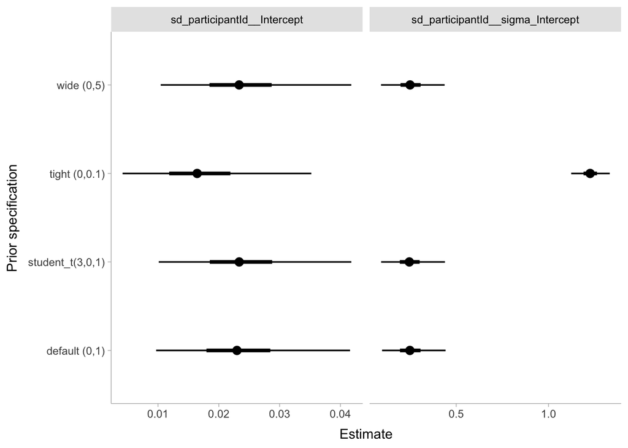

```r
combined_sd <- models %>%
  imap_dfr(
    ~ gather_draws(
      .x,
      sd_participantId__Intercept,
      sd_participantId__sigma_Intercept
    ) %>%
      mutate(prior = .y)
  )

combined_sd %>%
  ggplot(aes(x = .value, y = prior)) +
  stat_pointinterval(.width = c(.50, .95)) +
  facet_wrap(~.variable, scales = "free_x") +
  labs(x = "Estimate", y = "Prior specification")
```

**Takeaway**: posteriors were robust to prior specification across default, wide, and heavy-tailed priors. The tight prior $\sigma = 0.1$ constrained the residual variance parameter, confirming it is unreasonably informative for this parameter; the remaining three specifications produced essentially identical posteriors.

# Infer model for part 2

**Step 1:** Extract participant-level draws (20 participants $\times$ 3000 per chain $\times$ 4 chains)

```r
m1_draws_df <- m1 %>%
  spread_draws(
    b_Intercept,
    r_participantId[participantId, ],
    b_sigma_Intercept,
    r_participantId__sigma[participantId, ]
  ) %>%
  mutate(
    mu = b_Intercept + r_participantId,
    var_scale = exp(b_sigma_Intercept + r_participantId__sigma)
  ) %>%
  select(.draw, participantId, mu, var_scale)
```

**Step 2**: Then, we get a cross between participant and the stimuli they saw, in order to generate **predictions**:

```r
predict_df <- participant_df %>%
  rename(type = condition) %>%
  mutate(type = ifelse(type == "pointArc", "point_arc", "point")) %>%
  inner_join(
    stimuli_df %>% filter(type != "line") %>% rename(ogIndex = index),
    by = "type",
    relationship = "many-to-many"
  ) %>%
  unnest(col = data) %>%
  rename(num.ans.x = x, num.ans.y = y) %>%
  mutate(
    va.60 = x_moritz$data_to_va(60, distToScreen, pixelsPerMM),
    va.ans.x = x_moritz$data_to_va(num.ans.x, distToScreen, pixelsPerMM),
    va.ans.y = y_moritz$data_to_va(num.ans.y, distToScreen, pixelsPerMM),
  )

predict_df %>% head(5)
```

| participantId | pixelsPerMM | distToScreen | type | ogIndex | seed | noise | flip | num.ans.x | num.ans.y | va.60 | va.ans.x | va.ans.y |
| --- | --- | --- | --- | --- | --- | --- | --- | --- | --- | --- | --- | --- |
| 5c787104f5b67c0001d5b39d | 4.088785 | 744.8832 | point_arc | 8 | 1 | c(0, 0) | FALSE | 1.983672 | 0.7936596 | 4.700418 | 0.1554886 | 2.985425 |
| 5c787104f5b67c0001d5b39d | 4.088785 | 744.8832 | point_arc | 8 | 1 | c(0, 0) | FALSE | 3.419490 | 0.7500463 | 4.700418 | 0.2680337 | 2.821438 |
| 5c787104f5b67c0001d5b39d | 4.088785 | 744.8832 | point_arc | 8 | 1 | c(0, 0) | FALSE | 4.941859 | 0.7073340 | 4.700418 | 0.3873625 | 2.660827 |
| 5c787104f5b67c0001d5b39d | 4.088785 | 744.8832 | point_arc | 8 | 1 | c(0, 0) | FALSE | 6.529977 | 0.6653167 | 4.700418 | 0.5118441 | 2.502819 |
| 5c787104f5b67c0001d5b39d | 4.088785 | 744.8832 | point_arc | 8 | 1 | c(0, 0) | FALSE | 8.150882 | 0.6237192 | 4.700418 | 0.6388944 | 2.346381 |

## Project Once

**Step 3: Draw the posterior prediction for project once to the y-axis:**

Note that the following is going to take a while to run. On a mac mini it takes about 5 mins to fit.

```r
posterior_predict_df <- map_dfr(
  .progress = TRUE,
  unique(predict_df$participantId),
  function(pid) {
    # 12,000 draws for this participant
    d <- m1_draws_df %>%
      filter(participantId == pid) %>%
      arrange(.draw)

    # 2,880 observations (48 trials × 60 dots)
    obs <- predict_df %>%
      filter(participantId == pid) %>%
      select(ogIndex, va.60, va.ans.x, va.ans.y, pixelsPerMM, distToScreen)

    cross_join(d, obs) %>%
      mutate(
        sigma = var_scale * va.ans.x, # dist to y-axis is va.ans.x
        .prediction = rnorm(n(), mean = mu, sd = sigma),
        pred_y = va.ans.y + .prediction,
        w = 1 / (mu^2 + sigma^2) # inverse-mse
      ) %>%
      group_by(
        .draw,
        mu,
        var_scale,
        pixelsPerMM,
        distToScreen,
        va.60,
        ogIndex
      ) %>%
      summarise(
        va.1proj.mean = mean(pred_y),
        va.1proj.median = median(pred_y),
        va.1proj.weighted = sum(w * pred_y) / sum(w),
        .groups = "drop_last"
      ) %>%
      mutate(
        participantId = pid
      )
  }
)
```

```r
posterior_predict_df <- posterior_predict_df %>%
  mutate(
    num.1proj.mean = y_moritz$va_to_data(
      va.1proj.mean,
      distToScreen,
      pixelsPerMM
    ),
    num.1proj.median = y_moritz$va_to_data(
      va.1proj.median,
      distToScreen,
      pixelsPerMM
    ),
    num.1proj.weighted = y_moritz$va_to_data(
      va.1proj.weighted,
      distToScreen,
      pixelsPerMM
    )
  )
```

### Posterior checks with `bayesplot`

First we get the data in the right format to plot with `bayesplot`:

```r
# get the relevant ones for each strategy
response_ordered <- part2_df %>% arrange(participantId, ogIndex)
y <- response_ordered$num.resp.y

# group can be any condition-level variable, or a combination
group <- response_ordered %>%
  left_join(part2.ans_df %>% select(ogIndex, type, flip, noise)) %>%
  # we don't care about type, only care about noise and flip
  mutate(
    noise_label = ifelse(noise == "c(0, 0)", "Var 0", "Var 0.4"),
    flip_label = ifelse(flip == FALSE, "Var Lower", "Var Upper")
  ) %>%
  mutate(g = paste(noise_label, flip_label, sep = " | ")) %>%
  pull(g)

yrep_mean <- posterior_predict_df %>%
  ungroup() %>%
  select(participantId, ogIndex, .draw, num.1proj.mean) %>%
  arrange(participantId, ogIndex, .draw) %>%
  unite("obs_id", participantId, ogIndex) %>%
  pivot_wider(
    id_cols = .draw,
    names_from = obs_id,
    values_from = num.1proj.mean
  ) %>%
  select(-.draw) %>%
  as.matrix()

yrep_median <- posterior_predict_df %>%
  ungroup() %>%
  select(participantId, ogIndex, .draw, num.1proj.median) %>%
  arrange(participantId, ogIndex, .draw) %>%
  unite("obs_id", participantId, ogIndex) %>%
  pivot_wider(
    id_cols = .draw,
    names_from = obs_id,
    values_from = num.1proj.median
  ) %>%
  select(-.draw) %>%
  as.matrix()

yrep_weighted <- posterior_predict_df %>%
  ungroup() %>%
  select(participantId, ogIndex, .draw, num.1proj.weighted) %>%
  arrange(participantId, ogIndex, .draw) %>%
  unite("obs_id", participantId, ogIndex) %>%
  pivot_wider(
    id_cols = .draw,
    names_from = obs_id,
    values_from = num.1proj.weighted
  ) %>%
  select(-.draw) %>%
  as.matrix()
```

**KDE-Overlay**:

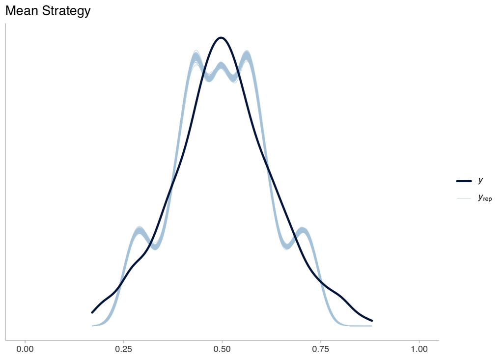

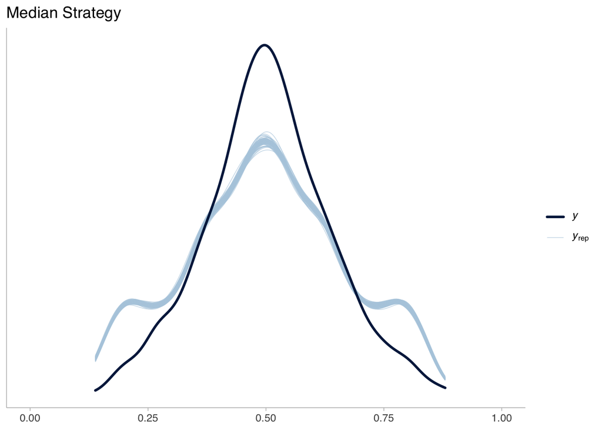

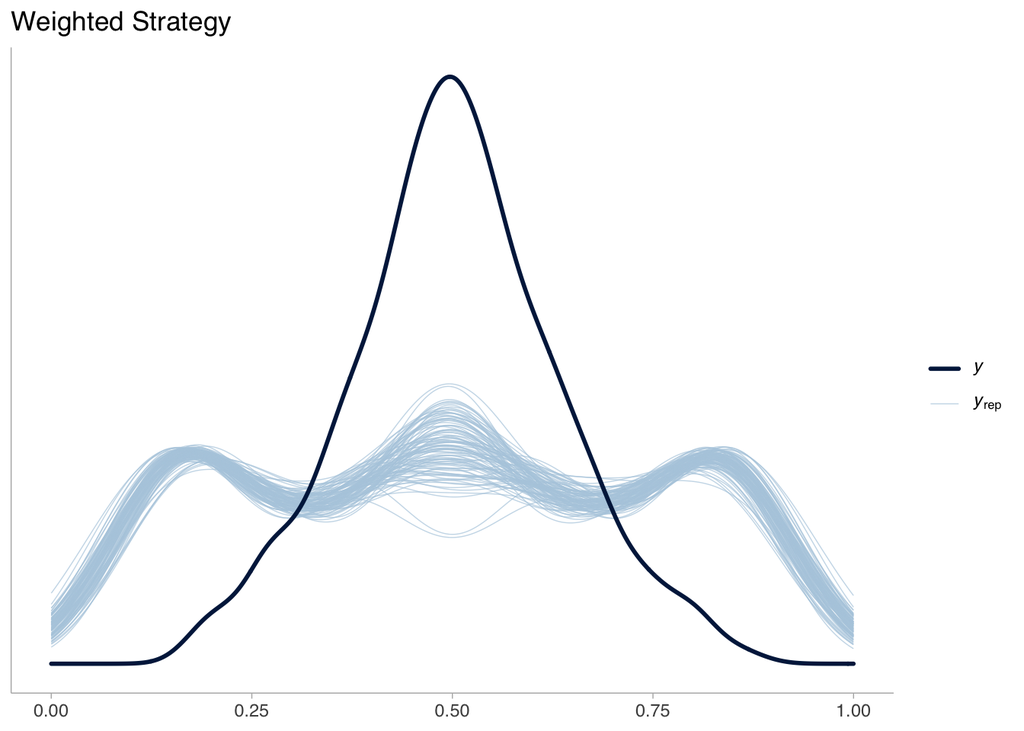

```r
ppc_dens_overlay(y, yrep_mean[sample(nrow(yrep_mean), 100), ]) +
  labs(title = "Mean Strategy") +
  coord_cartesian(xlim = c(0, 1))
ppc_dens_overlay(y, yrep_median[sample(nrow(yrep_median), 100), ]) +
  labs(title = "Median Strategy") +
  coord_cartesian(xlim = c(0, 1))
ppc_dens_overlay(y, yrep_weighted[sample(nrow(yrep_weighted), 100), ]) +
  labs(title = "Weighted Strategy") +
  coord_cartesian(xlim = c(0, 1))
```

**KDE-Overlay faceted by factor**:

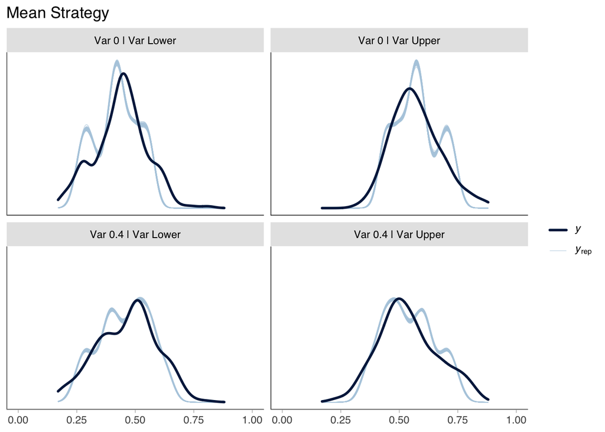

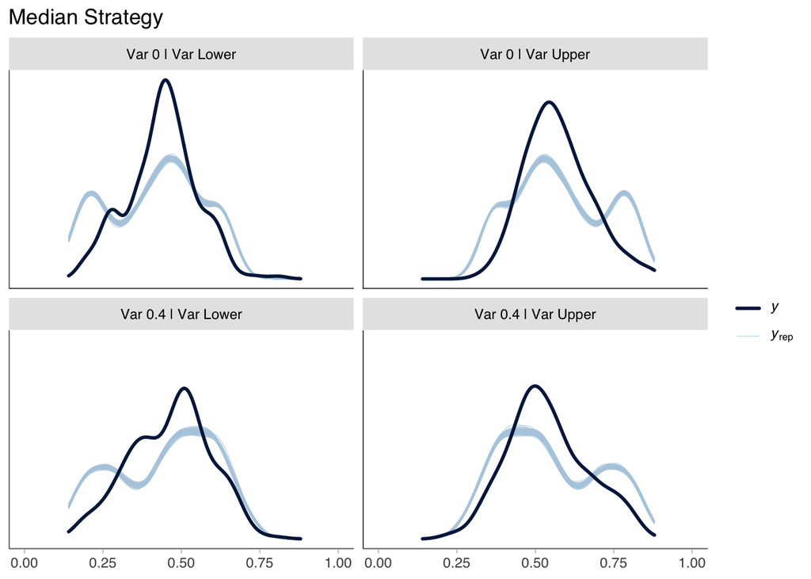

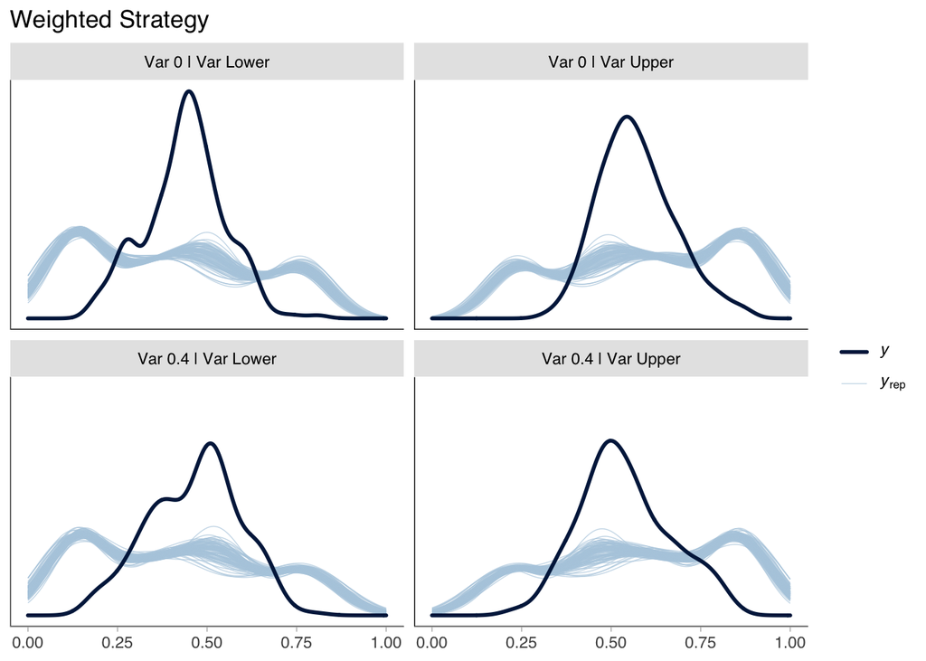

```r
p1 <- ppc_dens_overlay_grouped(
  y,
  yrep_mean[sample(nrow(yrep_mean), 100), ],
  group
) +
  labs(title = "Mean Strategy") +
  coord_cartesian(xlim = c(0, 1))
p2 <- ppc_dens_overlay_grouped(
  y,
  yrep_median[sample(nrow(yrep_median), 100), ],
  group
) +
  labs(title = "Median Strategy") +
  coord_cartesian(xlim = c(0, 1))
p3 <- ppc_dens_overlay_grouped(
  y,
  yrep_weighted[sample(nrow(yrep_weighted), 100), ],
  group
) +
  labs(title = "Weighted Strategy") +
  coord_cartesian(xlim = c(0, 1))
p1
p2
p3
```

**PIT-ECDFs**:

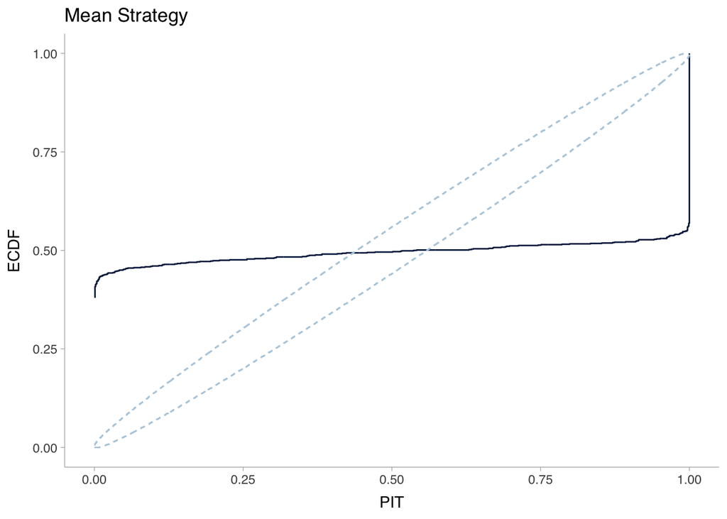

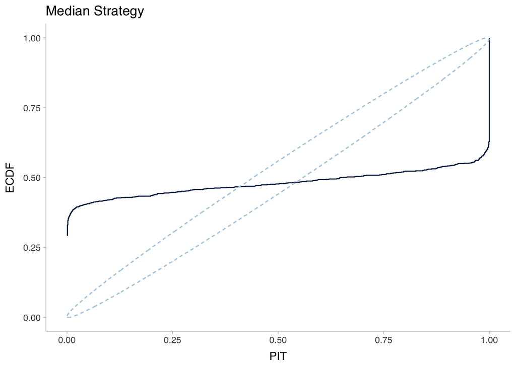

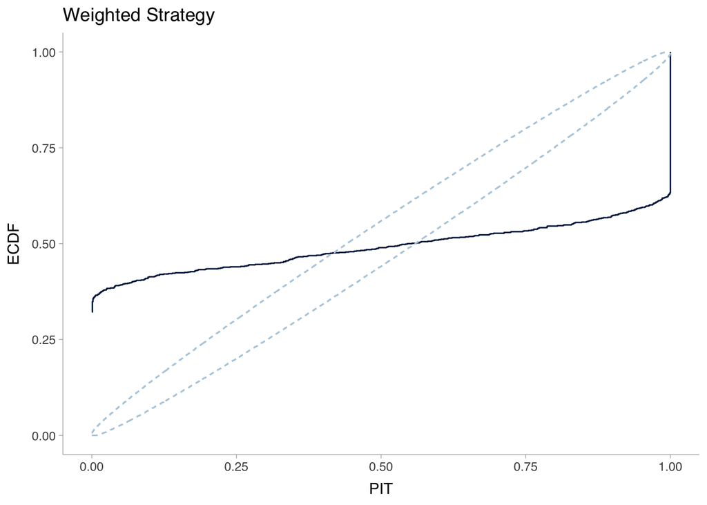

```r
ppc_pit_ecdf(y, yrep_mean) + labs(title = "Mean Strategy")
ppc_pit_ecdf(y, yrep_median) + labs(title = "Median Strategy")
ppc_pit_ecdf(y, yrep_weighted) + labs(title = "Weighted Strategy")
```

Faceted version:

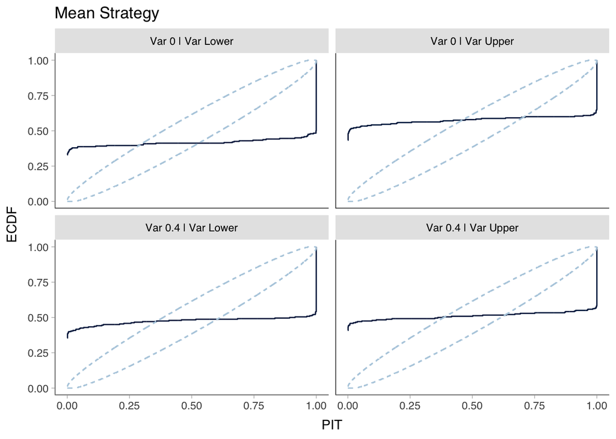

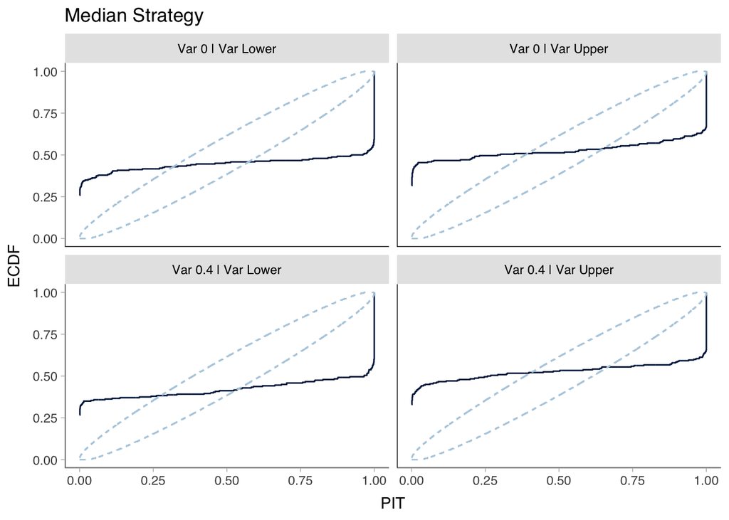

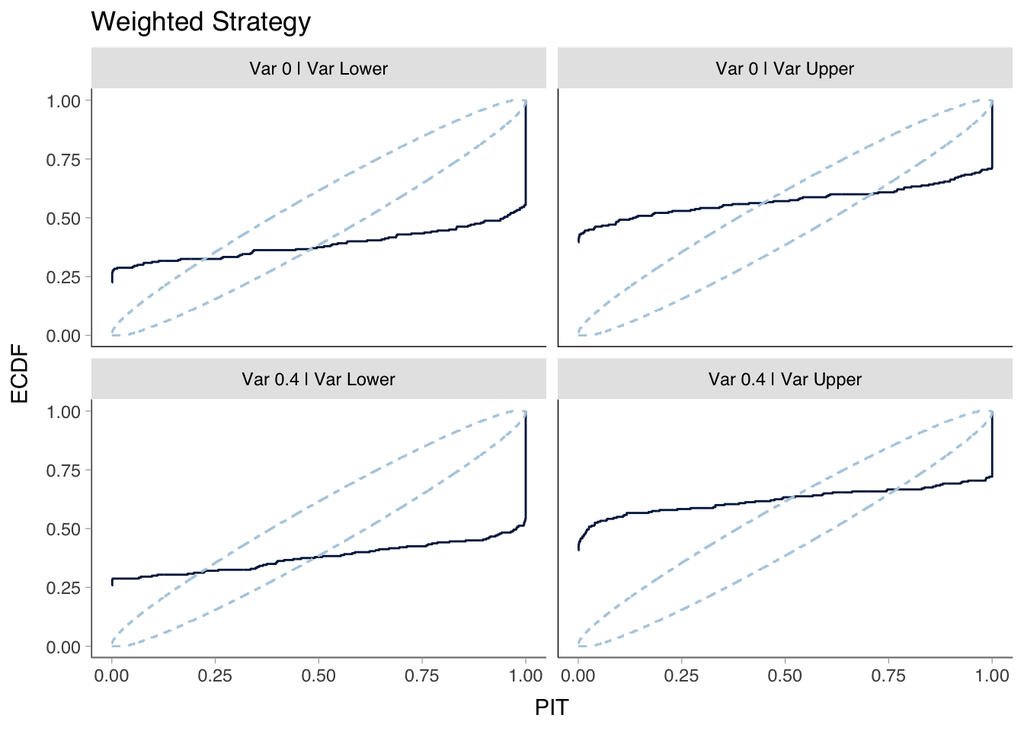

```r
ppc_pit_ecdf_grouped(y, yrep_mean, group) + labs(title = "Mean Strategy")
ppc_pit_ecdf_grouped(y, yrep_median, group) + labs(title = "Median Strategy")
ppc_pit_ecdf_grouped(y, yrep_weighted, group) +
  labs(title = "Weighted Strategy")
```

## Project Twice

Same step 1 and step 2 as before, so we don’t generate anything new, but start from step 3 with generating `posterior_predict_df`:

**Step 3: Draw the posterior prediction for project once to the middle AND project twice to the y-axis:**

Again, this is going to take a long time to run.

```r
posterior_predict_df <- map_dfr(
  .progress = TRUE,
  unique(predict_df$participantId),
  function(pid) {
    # 12,000 draws for this participant
    d <- m1_draws_df %>%
      filter(participantId == pid) %>%
      arrange(.draw)

    # 2,880 observations (48 trials × 60 dots)
    obs <- predict_df %>%
      filter(participantId == pid) %>%
      select(ogIndex, va.60, va.ans.x, va.ans.y, pixelsPerMM, distToScreen)

    cross_join(d, obs) %>%
      mutate(
        sigma = var_scale * abs(va.60 - va.ans.x), # dist to center
        .prediction = rnorm(n(), mean = mu, sd = sigma),
        pred_y = va.ans.y + .prediction,
        w = 1 / (mu^2 + sigma^2) # inverse-mse
      ) %>%
      group_by(
        .draw,
        mu,
        var_scale,
        pixelsPerMM,
        distToScreen,
        va.60,
        ogIndex
      ) %>%
      summarise(
        va.1proj.mean = mean(pred_y),
        va.1proj.median = median(pred_y),
        va.1proj.weighted = sum(w * pred_y) / sum(w),
        .groups = "drop_last"
      ) %>%
      mutate(
        proj_noise = rnorm(n(), mean = mu, sd = var_scale * va.60),
        va.2proj.mean = va.1proj.mean + proj_noise,
        va.2proj.median = va.1proj.median + proj_noise,
        va.2proj.weighted = va.1proj.weighted + proj_noise,
        participantId = pid
      )
  }
)
```

We then transform things from visual angle prediction to actual numerical value, for comparison against the actual response we got:

```r
posterior_predict_df <- posterior_predict_df %>%
  mutate(
    num.2proj.mean = y_moritz$va_to_data(
      va.2proj.mean,
      distToScreen,
      pixelsPerMM
    ),
    num.2proj.median = y_moritz$va_to_data(
      va.2proj.median,
      distToScreen,
      pixelsPerMM
    ),
    num.2proj.weighted = y_moritz$va_to_data(
      va.2proj.weighted,
      distToScreen,
      pixelsPerMM
    ),
  )
```

### Posterior Checks with `bayesplot`

First we get the data format ready to be plotted using `bayesplot`:

```r
response_ordered <- part2_df %>% arrange(participantId, ogIndex)
y <- response_ordered$num.resp.y

# group can be any condition-level variable, or a combination
group <- response_ordered %>%
  left_join(
    part2.ans_df %>%
      select(ogIndex, type, flip, noise)
  ) %>%
  mutate(
    noise_label = ifelse(noise == "c(0, 0)", "Var 0", "Var 0.4"),
    flip_label = ifelse(flip == FALSE, "Var Lower", "Var Upper")
  ) %>%
  mutate(g = paste(noise_label, flip_label, sep = " | ")) %>%
  pull(g)

yrep_mean <- posterior_predict_df %>%
  ungroup() %>%
  select(participantId, ogIndex, .draw, num.2proj.mean) %>%
  arrange(participantId, ogIndex, .draw) %>%
  unite("obs_id", participantId, ogIndex) %>%
  pivot_wider(
    id_cols = .draw,
    names_from = obs_id,
    values_from = num.2proj.mean
  ) %>%
  select(-.draw) %>%
  as.matrix()

yrep_median <- posterior_predict_df %>%
  ungroup() %>%
  select(participantId, ogIndex, .draw, num.2proj.median) %>%
  arrange(participantId, ogIndex, .draw) %>%
  unite("obs_id", participantId, ogIndex) %>%
  pivot_wider(
    id_cols = .draw,
    names_from = obs_id,
    values_from = num.2proj.median
  ) %>%
  select(-.draw) %>%
  as.matrix()

yrep_weighted <- posterior_predict_df %>%
  ungroup() %>%
  select(participantId, ogIndex, .draw, num.2proj.weighted) %>%
  arrange(participantId, ogIndex, .draw) %>%
  unite("obs_id", participantId, ogIndex) %>%
  pivot_wider(
    id_cols = .draw,
    names_from = obs_id,
    values_from = num.2proj.weighted
  ) %>%
  select(-.draw) %>%
  as.matrix()
```

**KDE-plots**:

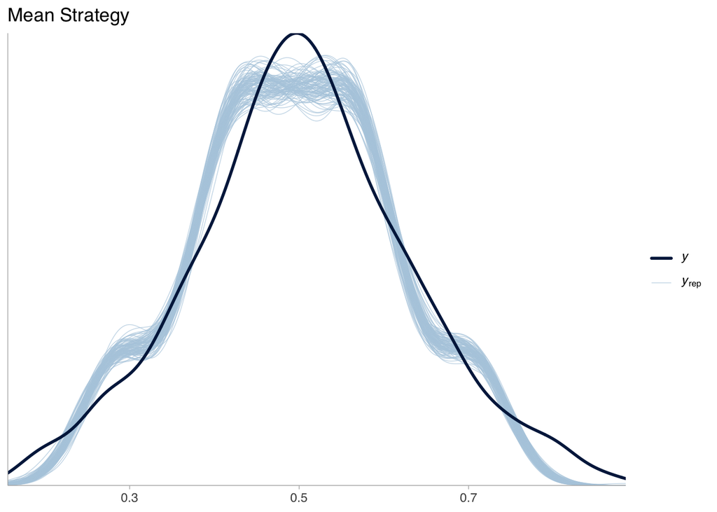

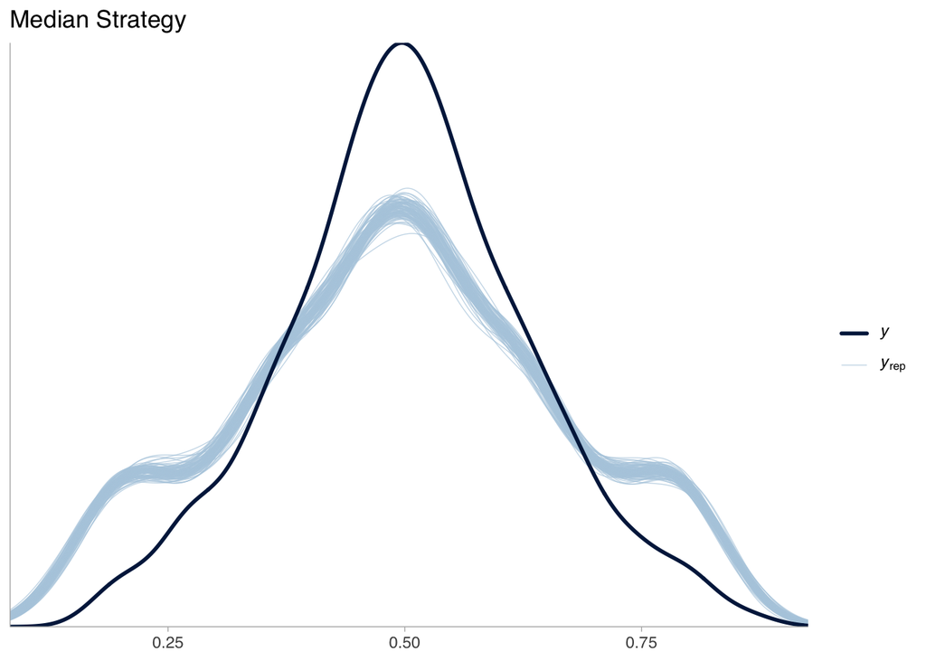

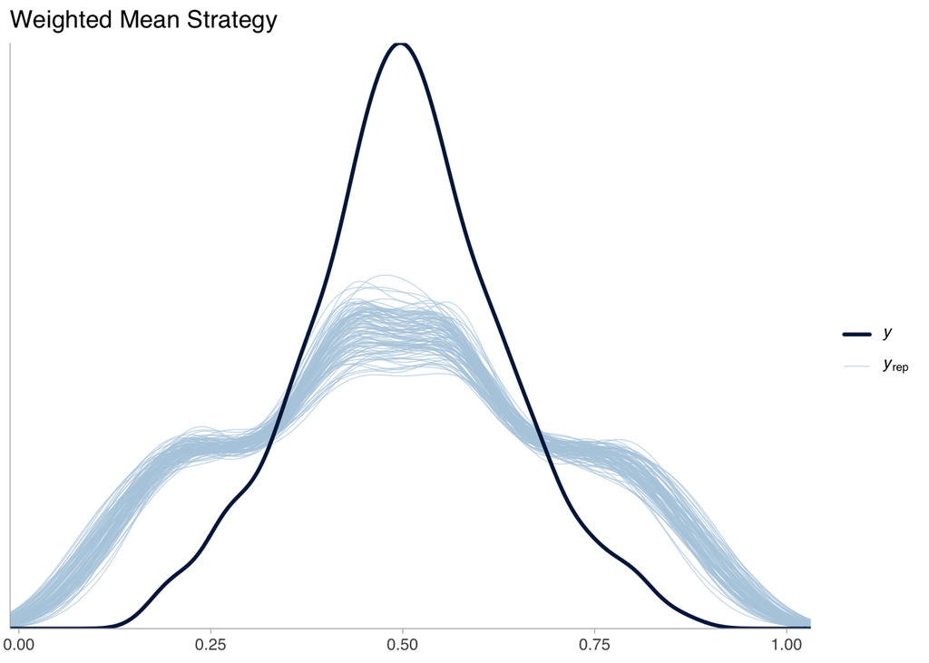

```r
ppc_dens_overlay(y, yrep_mean[sample(nrow(yrep_mean), 100), ]) +
  labs(title = "Mean Strategy")
ppc_dens_overlay(y, yrep_median[sample(nrow(yrep_median), 100), ]) +
  labs(title = "Median Strategy")
ppc_dens_overlay(y, yrep_weighted[sample(nrow(yrep_weighted), 100), ]) +
  labs(title = "Weighted Mean Strategy")
```

**KDE faceted**:

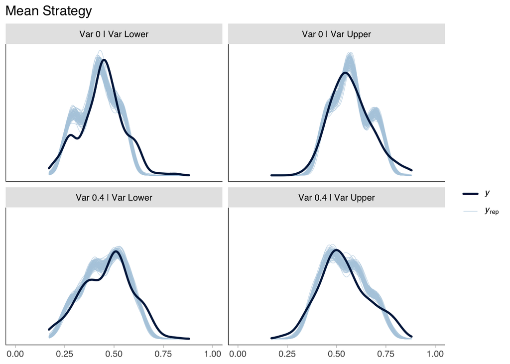

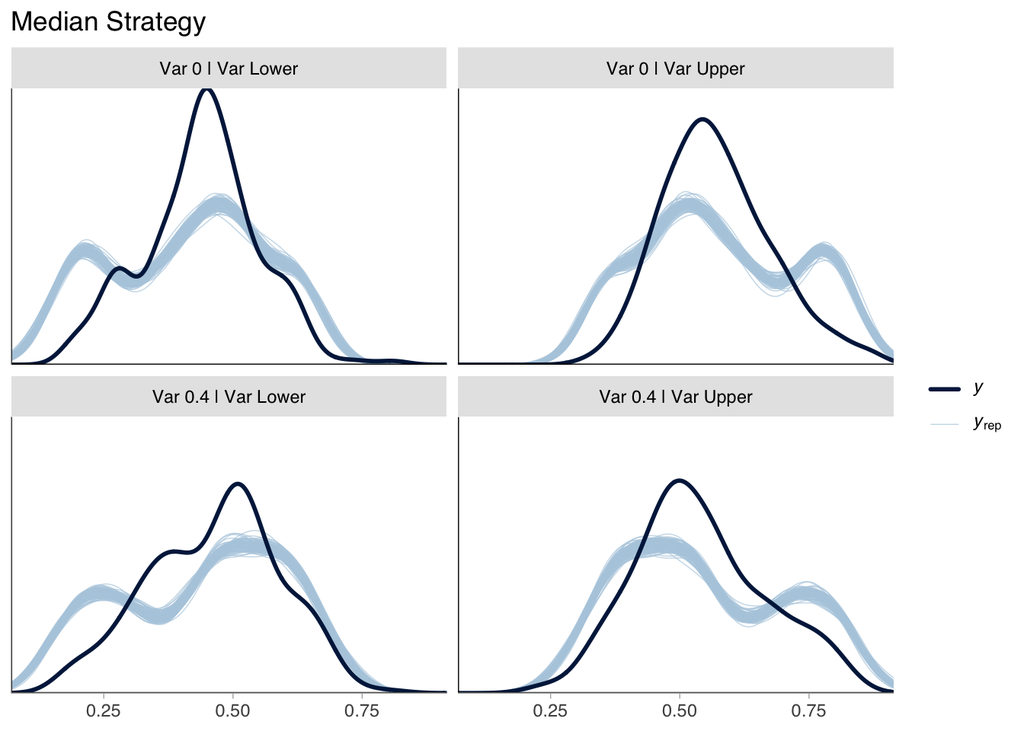

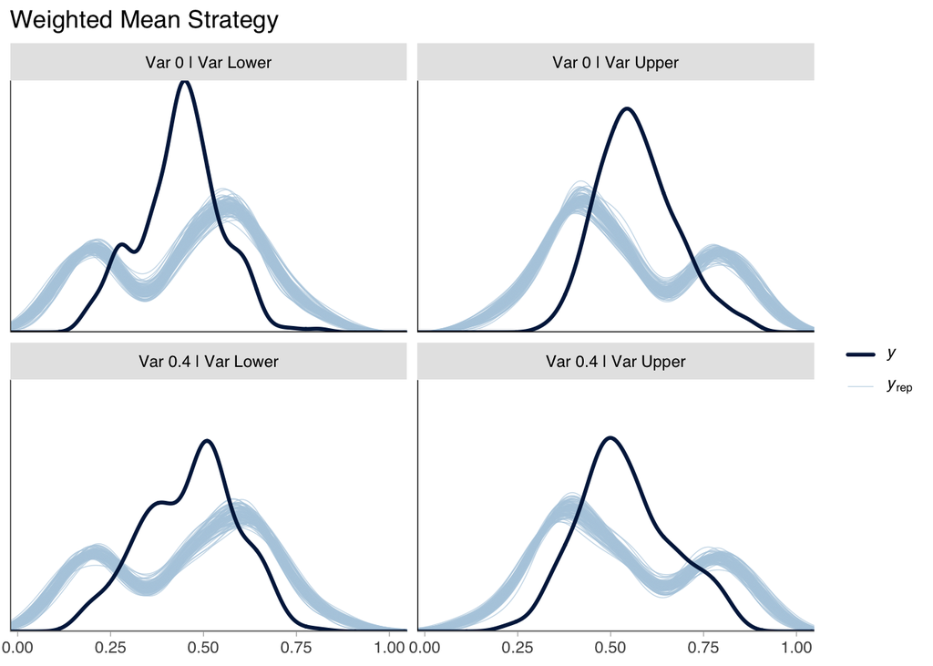

```r
p1 <- ppc_dens_overlay_grouped(
  y,
  yrep_mean[sample(nrow(yrep_mean), 100), ],
  group = group
) +
  labs(title = "Mean Strategy") +
  coord_cartesian(xlim = c(0, 1))
p2 <- ppc_dens_overlay_grouped(
  y,
  yrep_median[sample(nrow(yrep_median), 100), ],
  group = group
) +
  labs(title = "Median Strategy")
p3 <- ppc_dens_overlay_grouped(
  y,
  yrep_weighted[sample(nrow(yrep_weighted), 100), ],
  group = group
) +
  labs(title = "Weighted Mean Strategy")
p1
p2
p3
```